[figure not shown]

# 2D Scan Matcher using PyTorch

Exploring a 2D scan matcher implementation using PyTorch, focusing on solving the problem without explicitly computing correspondences for efficient and accurate results.

Published on March 19, 2023

The goal of scan matching is to find the relative pose between the two robot/sensor positions where the sensor measurements were taken.

I implemented a very simple point-to-point scan matcher in my [previous post](https://salihmarangoz.github.io/blog/2D-Scan-Matcher/). It is easy to compute the scan displacement when the correspondences are known. The same also works for point-to-line, line-to-line, and some other methods. But the matching performance depends on the computing of correspondences. In this post, I will show you how to implement a scan matcher without computing correspondences.

My implementation is basic and its computation complexity is pretty high. If you need something fast and robust, see NDT-based scan matching methods on open-source platforms. Anyway, I tested my approach on a realtime example (a 2D scanner with 270 points) and it worked quite well. Here is the video of my experiment:

[video not shown]

So, let's get started!

```python
from IPython.display import HTML
from matplotlib.animation import FuncAnimation
import matplotlib.pyplot as plt
import matplotlib
import numpy as np
import torch

print("PyTorch version:", torch.__version__)
print("Numpy version:", np.__version__)
print("Matplotlib version:", matplotlib.__version__)
```

```
PyTorch version: 1.13.0+cu117
Numpy version: 1.23.5
Matplotlib version: 3.6.2
```

## Load Laser Scan Data

I will be using the same data I used in my previous post.

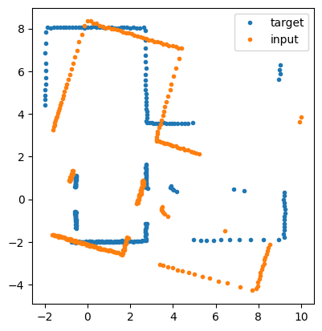

```python
angle_min = -2.35619449615
angle_max = 2.35619449615
angle_increment = 0.0174532923847
range_max = 15.0
ranges1 = np.load("laserdata1.npy")
ranges2 = np.load("laserdata2.npy")

# Convert from LaserScan to PointCloud
x1 = ranges1 * np.cos(np.arange(angle_min, angle_max, angle_increment))
y1 = ranges1 * np.sin(np.arange(angle_min, angle_max, angle_increment))
pc1 = np.stack([x1,y1])
x2 = ranges2 * np.cos(np.arange(angle_min, angle_max, angle_increment))
y2 = ranges2 * np.sin(np.arange(angle_min, angle_max, angle_increment))
pc2 = np.stack([x2,y2])

_=plt.plot(pc1[0], pc1[1], '.')
_=plt.plot(pc2[0], pc2[1], '.')
_=plt.legend(["target", "input"])
_=plt.gca().set_aspect('equal')
```

## Optimization

The runtime complexity is pretty high in this case. Excluding the optimization routine, the runtime complexity is $O(n^2)$. Since we don't have thousands of points here, I think it is ok for now to proceed without using some advanced techniques (e.g. NDT, KDTree).

```python
def sm_loss(pc1, pc2, r, T, variance=0.01):
    R = torch.stack([torch.cos(r), -torch.sin(r), torch.sin(r), torch.cos(r)]).reshape((2,2))
    pc1_t = torch.tensor(pc1)
    pc2_t = torch.tensor(pc2)

    # Rotate and translate pc2
    pc2_t_RT = R @ pc2_t + T.reshape(-1, 1)

    # Compute distance for each pair and use negative normal pdf as a loss
    x_diff = pc1_t[0,:].reshape(-1,1) - pc2_t_RT[0,:].reshape(1,-1)
    y_diff = pc1_t[1,:].reshape(-1,1) - pc2_t_RT[1,:].reshape(1,-1)
    residuals = torch.exp(-(x_diff**2+y_diff**2) / variance)
    return -torch.sum(residuals)
```

## Selecting Variance

Selecting a good variance value is important for achieving good results. In our case, I think $0.1$ is pretty ok.

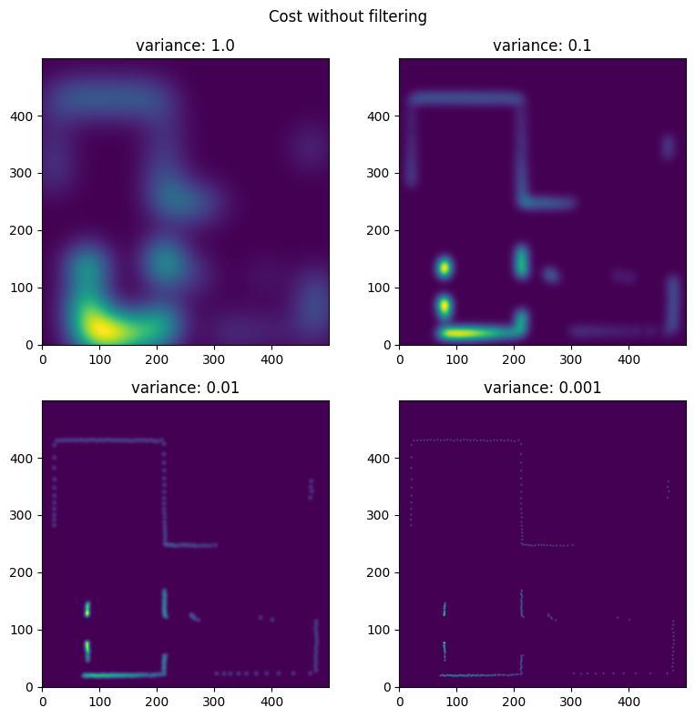

```python
def sm_loss_modified(pc1, pc2, r, T, variance=0.01):
    R = torch.stack([torch.cos(r), -torch.sin(r), torch.sin(r), torch.cos(r)]).reshape((2,2))
    pc1_t = torch.tensor(pc1)
    pc2_t = torch.tensor(pc2)
    pc2_t_RT = R @ pc2_t + T.reshape(-1, 1)
    x_diff = pc1_t[0,:].reshape(-1,1) - pc2_t_RT[0,:].reshape(1,-1)
    y_diff = pc1_t[1,:].reshape(-1,1) - pc2_t_RT[1,:].reshape(1,-1)
    residuals = torch.exp(-(x_diff**2+y_diff**2) / variance)
    return residuals

padding = 0.5
x_min, x_max = pc1[0].min()-padding, pc1[0].max()+padding
y_min, y_max = pc1[0].min()-padding, pc1[0].max()+padding

xls = np.linspace(x_min, x_max, 500)
yls = np.linspace(y_min, y_max, 500)
xx, yy = np.meshgrid(xls, yls, indexing="xy")

pc_grid = np.stack([xx.flatten(), yy.flatten()])

r = torch.tensor(0.0, dtype=torch.double)
T = torch.tensor([0., 0.], dtype=torch.double)

variances = [1.0, 0.1, 0.01, 0.001]
fig, axs = plt.subplots(2,2,figsize=(8,8))
axs = np.array(axs).flatten()

for var,ax in zip(variances,axs):
    residuals = torch.mean(sm_loss_modified(pc1, pc_grid, r, T, var), dim=0).numpy()
    img = residuals.reshape((len(yls), len(xls)))
    ax.imshow(img, origin='lower')
    ax.set_aspect('equal')
    ax.set_title('variance: ' + str(var))

fig.suptitle("Cost without filtering")
fig.tight_layout()
```

## Filtering

But as we can see there are some regions with high and low densities. It is caused because of the natura of laser scanner sensors. Closer the objects, more points we have. Filtering points in these high density regions is a need to achieve better performance in different cases.

### Voxel Filter

The idea is simply;

- Place all points into a 3D voxel grid.
- If there are more than 1 point, compute the mean and delete other points.
- Generate the pointcloud using the grid.

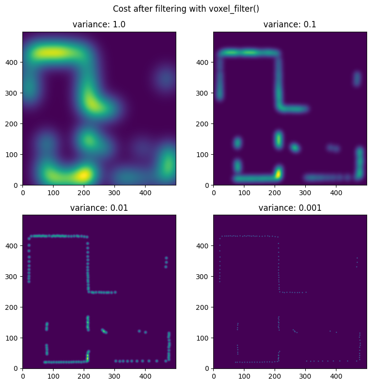

```python
def voxel_filter(pc, voxel_size):
    import open3d as o3d
    pc = np.stack([pc[0,:], pc[1,:], pc[1,:]*0]) # ugly trick
    pcd = o3d.geometry.PointCloud()
    pcd.points = o3d.utility.Vector3dVector(pc.T)
    pc = np.asarray(pcd.voxel_down_sample(voxel_size=voxel_size).points).T
    pc = pc[:2,:]
    return pc

pc1_voxel_filtered = voxel_filter(pc1, voxel_size=0.2)
pc2_voxel_filtered = voxel_filter(pc2, voxel_size=0.2)

fig, axs = plt.subplots(2,2,figsize=(8,8))
axs = np.array(axs).flatten()

for var,ax in zip(variances,axs):
    residuals = torch.mean(sm_loss_modified(pc1_voxel_filtered, pc_grid, r, T, var), dim=0).numpy()
    img = residuals.reshape((len(yls), len(xls)))
    ax.imshow(img, origin='lower')
    ax.set_aspect('equal')
    ax.set_title('variance: ' + str(var))

fig.suptitle("Cost after filtering with voxel_filter()")
fig.tight_layout()
```

### Minimum Distance Filter

I don't know the name is in the literature, but the idea is simply removing pairs with a distance lower than the threshold. This should help with the density problem. On the other hand, selecting a good `min_dist` is needed. If we set the value too high we can remove a lot of points than we need. If we set the value too low there will be density problems. So, I have set a maximum sensor range for the laser scanner and estimated a distance difference between consecutive laser rays. The idea is; what is the distance between two points when these points are generated from two consecutive rays and they are close to the maximum sensor range.

This is method is slower than the Voxel Filtering method, but the visualizations look better.

```python
distance_limit = 5.0
distance_change = 0.1 # max predicted dist difference between consecutive laser rays.
min_dist = 0.5 * distance_limit * (distance_limit + distance_change) * np.sin(angle_increment)
print(min_dist)
```

```
0.22251818035127538
```

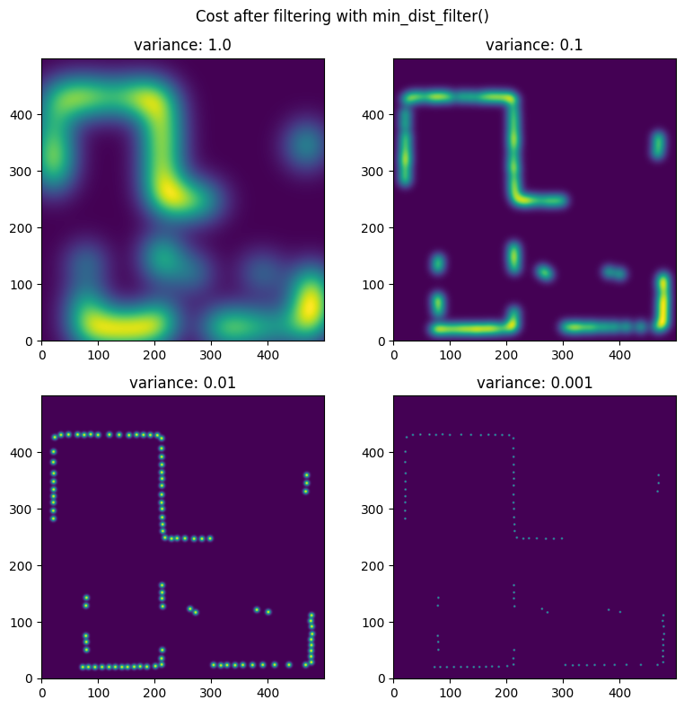

```python
def min_dist_filter(pc, min_dist):
    from fastpair import FastPair

    point_list = []
    for x,y in pc.T:
      point_list.append((x,y))

    fp = FastPair()
    fp.build(point_list)

    dist = 0
    while dist < min_dist:
        dist, (a, b) = fp.closest_pair()
        c = (a[0]/2+b[0]/2, a[1]/2+b[1]/2)
        fp -= b
        fp -= a
        fp += c

    return np.array(fp).T

pc1_min_dist_filtered = min_dist_filter(pc1, min_dist=min_dist)
pc2_min_dist_filtered = min_dist_filter(pc2, min_dist=min_dist)

fig, axs = plt.subplots(2,2,figsize=(8,8))
axs = np.array(axs).flatten()

for var,ax in zip(variances,axs):
    residuals = torch.mean(sm_loss_modified(pc1_min_dist_filtered, pc_grid, r, T, var), dim=0).numpy()
    img = residuals.reshape((len(yls), len(xls)))
    ax.imshow(img, origin='lower')
    ax.set_aspect('equal')
    ax.set_title('variance: ' + str(var))

fig.suptitle("Cost after filtering with min_dist_filter()")
fig.tight_layout()
```

## Experiments

```python
def optimize_and_visualize(select_optimizer, pc1, pc2, variance):
    r = torch.tensor(0.0, dtype=torch.double, requires_grad=True)
    T = torch.tensor([0., 0.], dtype=torch.double, requires_grad=True)
    params = [r, T]

    if select_optimizer.startswith("LBFGS"):
        optimizer = torch.optim.LBFGS(params, lr=1, max_iter=1, tolerance_grad=1e-07, tolerance_change=1e-09, history_size=100, line_search_fn="strong_wolfe")
    if select_optimizer.startswith("Rprop"):
        optimizer = torch.optim.Rprop(params, lr=0.01, etas=(0.1, 1.1), step_sizes=(0.00001, 50))
    if select_optimizer.startswith("SGD"):
        optimizer =torch.optim.SGD(params, lr=0.0001, weight_decay=0)
    if select_optimizer.startswith("Adam"):
        optimizer = torch.optim.Adam(params, lr=0.1, betas=(0.8, 0.999), eps=1e-08, weight_decay=0)

    fig, ax = plt.subplots()
    fig.set_size_inches(4, 4)
    p1, = plt.plot(pc1[0, :], pc1[1, :], ".")
    p2, = plt.plot([], [], ".")
    _=plt.gca().set_aspect('equal')
    plt.title(select_optimizer)
    fig.tight_layout()

    def init():
        return p1, p2,

    def closure():
        optimizer.zero_grad()
        loss = sm_loss(pc1, pc2, r, T, variance)
        loss.backward()
        return loss

    def update(frame):
        if (frame == 0):
            R = torch.stack([torch.cos(r), -torch.sin(r), torch.sin(r), torch.cos(r)]).reshape((2,2))
            pc2_plot = (R.detach().numpy() @ pc2 + T.reshape(-1, 1).detach().numpy())
            p2.set_data(pc2_plot[0, :], pc2_plot[1, :])
            return p1, p2,

        optimizer.zero_grad()
        loss = sm_loss(pc1, pc2, r, T, variance)
        loss.backward()
        optimizer.step(closure)
        R = torch.stack([torch.cos(r), -torch.sin(r), torch.sin(r), torch.cos(r)]).reshape((2,2))
        pc2_plot = (R.detach().numpy() @ pc2 + T.reshape(-1, 1).detach().numpy())
        p2.set_data(pc2_plot[0, :], pc2_plot[1, :])
        return p1, p2,

    ani = FuncAnimation(fig, update, frames=25,
                        init_func=init, blit=True)

    plt.close()
    return ani.to_html5_video()
```

### Adam + Minimum Distance Filter + variance=0.1

```python
HTML(optimize_and_visualize("Adam, min_dist_filter, variance=0.1", pc1_min_dist_filtered, pc2_min_dist_filtered, variance=0.1))
```

[video not shown]

### Rprop + Minimum Distance Filter + variance=0.1

```python
HTML(optimize_and_visualize("Rprop, min_dist_filter, variance=0.1", pc1_min_dist_filtered, pc2_min_dist_filtered, variance=0.1))
```

[video not shown]

### Rprop + No Filter + variance=0.1

```python
HTML(optimize_and_visualize("Rprop, raw points, variance=0.1", pc1, pc2, variance=0.1))
```

[video not shown]

### LBFGS + Minimum Distance Filter + variance=0.1

```python
HTML(optimize_and_visualize("LBFGS, min_dist_filter, variance=0.1", pc1_min_dist_filtered, pc2_min_dist_filtered, variance=0.1))
```

[video not shown]

### LBFGS + Voxel Filter + variance=0.1

```python
HTML(optimize_and_visualize("LBFGS, voxel_filter, variance=0.1", pc1_voxel_filtered, pc2_voxel_filtered, variance=0.1))
```

[video not shown]

### LBFGS + No Filter + variance=0.1

```python
HTML(optimize_and_visualize("LBFGS, raw points, variance=0.1", pc1, pc2, variance=0.1))
```

[video not shown]

## Closing Thoughts

The implemented scan matcher is not super nice, robust, nor fast, as seen we can see in the Youtube video. But, I did enjoy implementing and seeing it worked. If you would like to do something like this, please check NDT and other methods before starting. I would recommend using [JAX](https://jax.readthedocs.io/en/latest/), since it is similar to PyTorch in the autograd context but more advanced. Also check [JAXopt](https://jaxopt.github.io/stable/index.html) for more methods. It is not possible to set parameter boundaries with LBFGS but it is possible with Levenberg–Marquardt. If you would like to do something similar in C/C++ there is a library named [Ceres Solver](http://ceres-solver.org/), but I would high recommend learning JAX because the number of extension libraries are pretty high in comparison. See the list [here](https://github.com/n2cholas/awesome-jax).

Whatever you research or code, don't forget to have fun!